# Image Compression with Principal Components Analysis

Ayaan Karim-Ali

September 24, 2026

## Overview

An image stored as an $n \times p$ matrix $X$ can be rebuilt from its principal components. Writing the eigendecomposition of the cross product as $X'X = U \Lambda U'$ and setting $Z = XU$ gives the identity $X = ZU'$, because $U$ is orthonormal. Keeping only the first $k$ columns of $Z$ and $U$ produces the rank $k$ approximation

$$X^{(k)} = z_1u_1' + z_2u_2' +
\cdots + z_ku_k'$$

which stores $k(n + p)$ numbers instead of $n \times p$. The error of that approximation is measured by the Frobenius norm of $X - X^{(k)}$.

The columns of $X$ are not centered before the decomposition. Centering is the usual first step in PCA, as in Section 12.2 of *An Introduction to Statistical Learning*, but the target here is the stored values themselves, and working with $X$ as stored keeps the identity $X = ZU'$ exact without a separate vector of column means. Each eigenvalue is then the sum of squares of the image along its direction, and the eigenvalues add up to the sum of every squared entry of $X$. When this page reports the proportion of variation held by the first $k$ components, it means the share of that total.

The same bookkeeping ties the two main measures on this page together. The squared Frobenius error at rank $k$ equals the sum of the eigenvalues left out, so the error curve and the proportion of variation are two views of one quantity. The decomposition of total variation in equation 12.11 of that chapter says the same thing for centered data.

## The compression function

The function below takes an image matrix and a rank $k$, and returns the rank $k$ approximation along with its Frobenius error.

```r
## Compute the rank-k approximation to an image matrix using PCA.
##
##   x : an n x p numeric matrix holding the image
##   k : the rank of the approximation, an integer from 1 to p
##
## Returns a list holding the approximation, its Frobenius error, and k.
compress_image <- function(x, k) {
        x <- data.matrix(x)
        p <- ncol(x)

        if (k < 1 || k > p)
                stop("k must be between 1 and ", p)

        ## Eigendecomposition of the cross product V = X'X.  V is symmetric,
        ## so eigen() returns the eigenvalues in decreasing order and the
        ## first column of U is the leading eigenvector.
        v <- crossprod(x)
        e <- eigen(v, symmetric = TRUE)
        u <- e$vectors

        ## Z = XU holds the principal component scores
        z <- x %*% u

        ## The rank-k approximation is the sum of the first k outer products
        ## z_j u_j', which equals Z[, 1:k] U[, 1:k]'
        approx <- z[, 1:k, drop = FALSE] %*% t(u[, 1:k, drop = FALSE])

        list(approximation = approx,
             error = norm(x - approx, type = "F"),
             k = k)
}
```

Two checks confirm the function behaves as the identity above requires. At $k = p$ the approximation should reproduce the original matrix exactly, and the error should fall to zero.

```r
x <- data.matrix(read_csv("image3.csv"))

## An intermediate rank
compress_image(x, 10)$error
```

```
## [1] 79.13073
```

```r
## The full rank approximation returns the original matrix back
full <- compress_image(x, ncol(x))
full$error
```

```
## [1] 6.92858e-13
```

```r
max(abs(x - full$approximation))
```

```
## [1] 1.409983e-14
```

Both numbers at full rank sit at the level of floating point rounding, so the function returns $X$ exactly when every component is kept.

## Supporting functions

Calling `compress_image()` separately for every rank would repeat the eigendecomposition hundreds of times, so the error curve uses a version that decomposes once and then adds one outer product at a time. A check at the end of this section confirms the two agree.

Every panel in a row of approximations is shaded on the original image’s grey scale, with the original’s smallest value in black and its largest in white, so equal values look equal from one panel to the next. Values in an approximation that fall outside that range are drawn at the nearest end. The panels for images 3 and 4 keep the true proportions of each image. Images 1 and 2 are ten times taller than they are wide, so their panels are stretched sideways to keep single columns visible.

Eigenvectors are only defined up to a sign change, and flipping the sign of $u_1$ and $z_1$ together leaves $z_1u_1'$ unchanged. The eigenvector plots fix the sign so that the largest weight is positive, which makes the plots for the four images comparable.

```r
## Frobenius error for every rank from 1 to p
compression_errors <- function(x) {
        x <- data.matrix(x)
        p <- ncol(x)

        e <- eigen(crossprod(x), symmetric = TRUE)
        u <- e$vectors
        z <- x %*% u

        approx <- matrix(0, nrow(x), p)
        err <- numeric(p)

        for (k in seq_len(p)) {
                approx <- approx + z[, k] %o% u[, k]
                err[k] <- norm(x - approx, type = "F")
        }
        data.frame(k = seq_len(p), error = err)
}

## Eigenvalues of X'X, largest first.  Values that come out a hair below
## zero from rounding are set to zero.
eigenvalues <- function(x) {
        lambda <- eigen(crossprod(data.matrix(x)), symmetric = TRUE,
                        only.values = TRUE)$values
        pmax(lambda, 0)
}

## Smallest k whose first k components hold at least the given share of the
## total sum of squares
components_needed <- function(lambda, share) {
        which(cumsum(lambda) / sum(lambda) >= share)[1]
}

## Storage for a rank-k approximation as a percentage of the original
storage_percent <- function(x, k) {
        100 * k * (nrow(x) + ncol(x)) / (nrow(x) * ncol(x))
}

## Draw a matrix as a greyscale image.  image() treats the first index as the
## horizontal axis, so the matrix is transposed and its rows reversed to come
## out in the orientation we expect.  zlim sets the grey scale, and
## keep_shape = TRUE draws the image in its true proportions.
show_image <- function(x, title = "", zlim = range(x), keep_shape = TRUE) {
        x <- pmin(pmax(x, zlim[1]), zlim[2])
        image(t(x)[, nrow(x):1], zlim = zlim,
              col = grey(seq(0, 1, length.out = 256)),
              axes = FALSE, main = title, useRaster = TRUE,
              asp = if (keep_shape) nrow(x) / ncol(x) else NA)
}

## The original image followed by the first ten approximations
plot_approximations <- function(x, per_row = 11, keep_shape = TRUE) {
        x <- data.matrix(x)
        op <- par(mfrow = c(ceiling(11 / per_row), per_row),
                  mar = c(0.5, 0.5, 2, 0.5))
        on.exit(par(op))
        show_image(x, "Original", keep_shape = keep_shape)
        for (k in 1:10)
                show_image(compress_image(x, k)$approximation,
                           paste0("k = ", k), zlim = range(x),
                           keep_shape = keep_shape)
}

## The original next to larger views of selected ranks
plot_selected <- function(x, ks) {
        x <- data.matrix(x)
        op <- par(mfrow = c(1, length(ks) + 1), mar = c(0.5, 0.5, 3, 0.5))
        on.exit(par(op))
        show_image(x, "Original")
        for (k in ks)
                show_image(compress_image(x, k)$approximation,
                           paste0("k = ", k, ", ",
                                  round(storage_percent(x, k)),
                                  "% of original size"),
                           zlim = range(x))
}

## Frobenius error against rank, for every possible rank
plot_error_curve <- function(x, name) {
        d <- compression_errors(x)
        op <- par(mar = c(4.5, 4.5, 3, 1))
        on.exit(par(op))
        plot(d$k, d$error, type = "l", lwd = 2, col = "steelblue",
             xlab = "Rank k", ylab = "Frobenius error",
             main = paste("Approximation error vs. k:", name))
        points(d$k[1:10], d$error[1:10], pch = 19, col = "darkorange", cex = 0.8)
        grid(col = "grey90")
        invisible(d)
}

## The first eigenvector and the first PC score, with the sign fixed so that
## the largest weight in the eigenvector is positive
plot_first_components <- function(x, name) {
        x <- data.matrix(x)
        e <- eigen(crossprod(x), symmetric = TRUE)
        u1 <- e$vectors[, 1]
        if (u1[which.max(abs(u1))] < 0)
                u1 <- -u1
        z1 <- as.vector(x %*% u1)

        op <- par(mfrow = c(1, 2), mar = c(4.5, 4.5, 3, 1))
        on.exit(par(op))
        plot(u1, type = "l", lwd = 2, col = "firebrick",
             xlab = "Column of the image", ylab = "Weight",
             main = paste("First eigenvector:", name))
        abline(h = 0, lty = 3, col = "grey50")
        plot(z1, type = "l", lwd = 2, col = "darkgreen",
             xlab = "Row of the image", ylab = "Score",
             main = paste("First PC score:", name))
        abline(h = 0, lty = 3, col = "grey50")

        invisible(list(u1 = u1, z1 = z1))
}

## Proportion of the total held by the first k components
variance_table <- function(x, ks = c(1, 2, 5, 10, 20, 50)) {
        lambda <- eigenvalues(x)
        cum <- cumsum(lambda) / sum(lambda)
        ks <- ks[ks <= length(lambda)]
        data.frame(k = ks, cumulative_proportion = round(cum[ks], 4))
}

## Scree plot: proportion of the total held by each of the first m components
plot_scree <- function(lambda, name, m = 20) {
        m <- min(m, length(lambda))
        prop <- lambda / sum(lambda)
        op <- par(mar = c(4.5, 4.5, 3, 1))
        on.exit(par(op))
        plot(seq_len(m), prop[1:m], type = "b", pch = 19, col = "purple4",
             ylim = c(0, 1), xlab = "Principal component",
             ylab = "Proportion of variation",
             main = paste("Scree plot, first", m, "components:", name))
        grid(col = "grey90")
}
```

```r
## The fast error curve agrees with the direct function at k = 10
all.equal(compression_errors(x)$error[10], compress_image(x, 10)$error)
```

```
## [1] TRUE
```

## Image 1

```r
img1 <- data.matrix(read_csv("image1.csv"))
dim(img1)
```

```
## [1] 1000  100
```

```r
range(img1)
```

```
## [1] -4.174029 22.463964
```

### Original and the first ten approximations

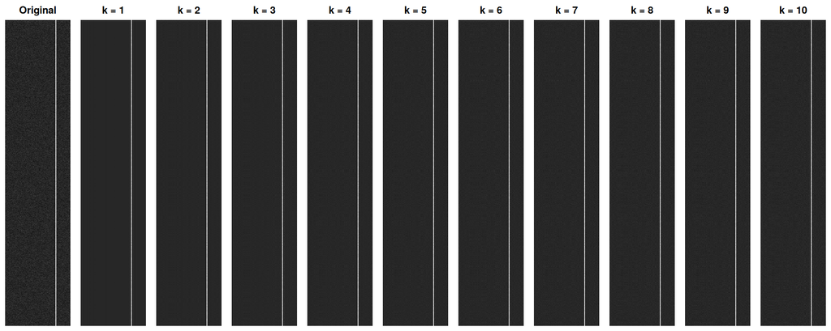

```r
plot_approximations(img1, keep_shape = FALSE)
```

### Approximation error

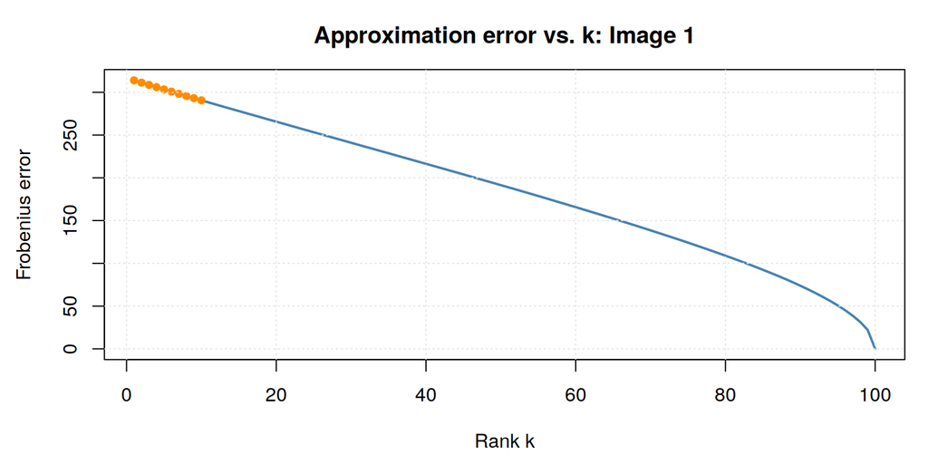

```r
err1 <- plot_error_curve(img1, "Image 1")
```

```r
variance_table(img1)
```

```
##    k cumulative_proportion
## 1  1                0.8019
## 2  2                0.8053
## 3  5                0.8151
## 4 10                0.8304
## 5 20                0.8582
## 6 50                0.9264
```

### First eigenvector and first PC score

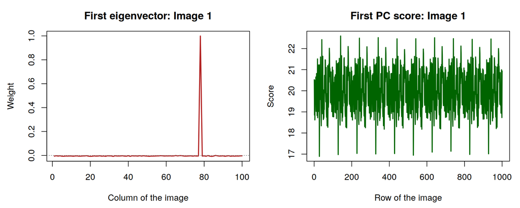

```r
c1 <- plot_first_components(img1, "Image 1")
```

```r
## The column carrying the large weight, and the largest weight elsewhere
spike <- which.max(abs(c1$u1))
spike
```

```
## [1] 78
```

```r
max(abs(c1$u1[-spike]))
```

```
## [1] 0.007932368
```

```r
## Range of the scores, and the scores against themselves 100 rows later
range(c1$z1)
```

```
## [1] 16.89276 22.59331
```

```r
cor(c1$z1[1:900], c1$z1[101:1000])
```

```
## [1] 0.9977442
```

**Interpretation.** The first eigenvector is flat at zero across the width of the image apart from one spike. Column 78 carries a weight of 0.999, and no other weight is larger than 0.008 in size. An eigenvector assigns one weight to each column, so a single spike means the first component reads one column and ignores the rest of the width. That column is the bright vertical line in the original.

The first PC score gives one value per row and measures how strongly each row expresses the pattern. With nearly all of the weight on one column, each score is close to the value of the line in that row. The scores stay between 16.9 and 22.6, so the line keeps a steady brightness from top to bottom. The score plot also shows ten matching cycles, with the same dips and peaks recurring every 100 rows, and the scores correlate at 0.998 with themselves shifted down by 100 rows. The brightness along the line is one sequence of 100 values repeated ten times. The rank 1 approximation places that sequence in column 78 and leaves the rest of the frame close to zero, which is what the $k = 1$ panel shows.

### How large does $k$ need to be?

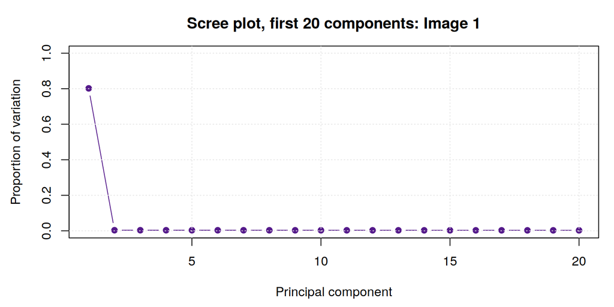

```r
lambda1 <- eigenvalues(img1)
plot_scree(lambda1, "Image 1")
```

The scree plot has one point far above the rest. The first eigenvalue is 399,104, and the other 99 sit between 490 and 1,676, so even the largest of them is about 238 times smaller than the first. They decline evenly, with no second break anywhere in the tail. Eigenvalues that stay in a narrow band with no break are what independent noise produces, because noise has no preferred direction and spreads its sum of squares across all of them.

The error curve shows the same thing from the other side. With no components the error equals the size of the image itself, 705, and the first component cuts it to 314. After that the curve falls in a nearly straight line to zero, each added component removing a similar small slice of noise. From $k = 2$ onward the approximation panels only add grain to the background.

**I would stop at $k = 1$ for this image.** The bright line is the only structure present, and the rank 1 approximation reproduces it, repeating pattern included. The remaining 99 components rebuild noise. Chasing a lower Frobenius error here would mean spending storage to rebuild randomness, which works against the purpose of compression. At $k = 1$ the image takes 1,100 numbers instead of 100,000.

## Image 2

```r
img2 <- data.matrix(read_csv("image2.csv"))
dim(img2)
```

```
## [1] 1000  100
```

```r
range(img2)
```

```
## [1] -694.4353  614.6343
```

### Original and the first ten approximations

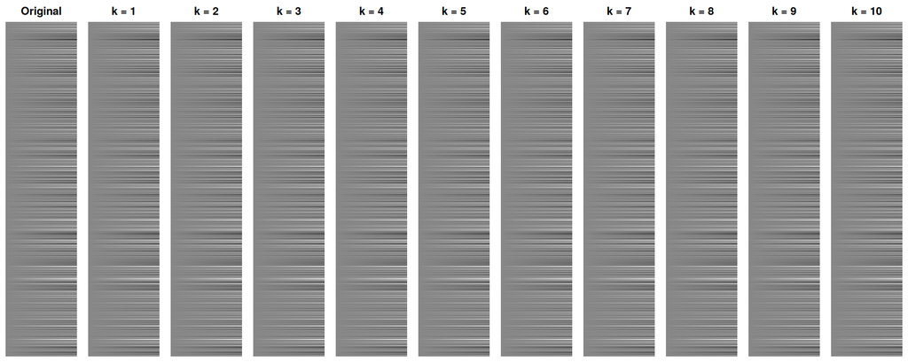

```r
plot_approximations(img2, keep_shape = FALSE)
```

### Approximation error

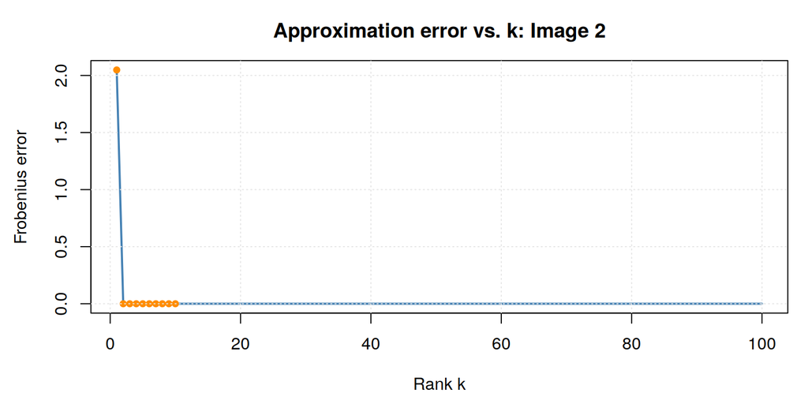

```r
err2 <- plot_error_curve(img2, "Image 2")
```

```r
variance_table(img2)
```

```
##    k cumulative_proportion
## 1  1                     1
## 2  2                     1
## 3  5                     1
## 4 10                     1
## 5 20                     1
## 6 50                     1
```

### First eigenvector and first PC score

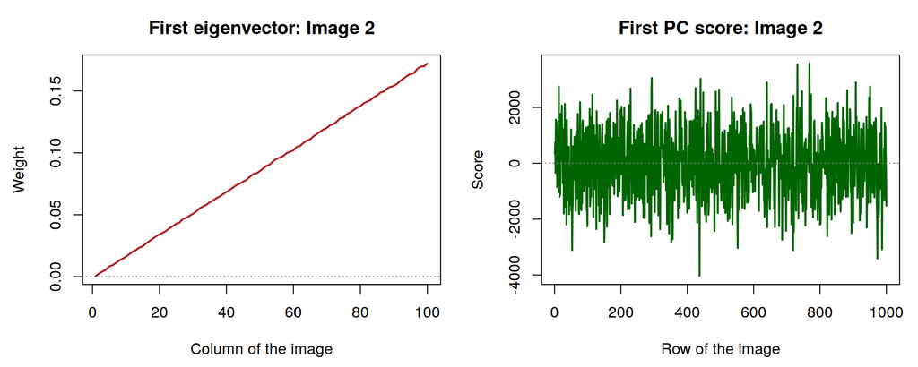

```r
c2 <- plot_first_components(img2, "Image 2")
```

```r
## How closely the weights follow the column number
cor(c2$u1, seq_along(c2$u1))
```

```
## [1] 0.9999622
```

```r
## How closely the scores follow the row averages
cor(c2$z1, rowMeans(img2))
```

```
## [1] 1
```

**Interpretation.** The first eigenvector is a straight line. Its weights rise in equal steps from 0.0006 at the first column to 0.172 at the last, and they correlate with the column number at 1.0000. Every weight has the same sign and grows with its column number, so the pattern the component describes is a ramp, a steady change in brightness from the left edge of the image to the right.

The first PC score gives one number per row, and it scatters on both sides of zero with no trend down the image. Each row of the rank 1 approximation is the same ramp multiplied by that row’s score. A row with a large positive score brightens quickly from left to right, a row with a large negative score darkens at the same rate, and a row with a score near zero stays flat. The original matches this description: every row starts at nearly the same grey on the left edge, and the rows spread apart toward the right, which produces the stripes. The scores also correlate with the row averages at 1.0000, since the average of a scaled ramp is the ramp’s average times the score.

### How large does $k$ need to be?

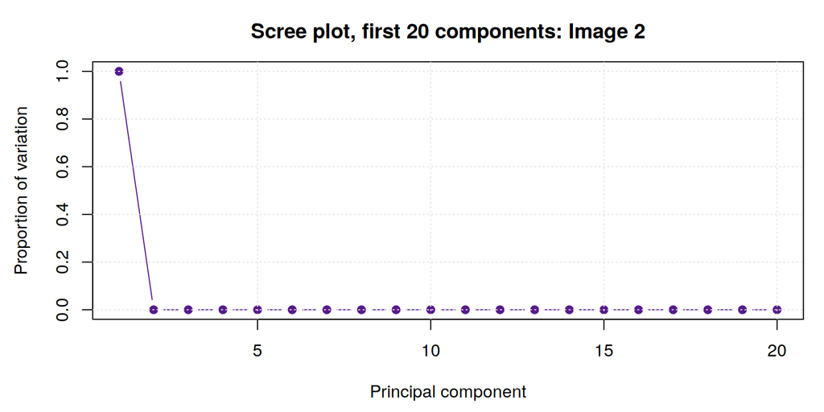

```r
lambda2 <- eigenvalues(img2)
plot_scree(lambda2, "Image 2")
```

The first eigenvalue holds essentially the entire sum of squares. The second is 4.2 against a total of 1,409,160,781, and every later eigenvalue is smaller still, so the scree plot is a single point at one followed by zeros. The image is effectively a rank 1 matrix stored as 1,000 by 100 numbers. The error curve agrees. The error at $k = 1$ is already down to 2.05, against 37,539 for the image as a whole, and it is essentially zero from $k = 2$ on.

**$k = 1$ is enough here, and the case is stronger than for any of the other three images.** The $k = 1$ panel cannot be told apart from the original. The image compresses from 100,000 numbers to 1,100, about 1% of its original size, with no loss anyone could see.

## Image 3

```r
img3 <- data.matrix(read_csv("image3.csv"))
dim(img3)
```

```
## [1] 376 345
```

```r
range(img3)
```

```
## [1] -2.200936  1.517384
```

### Original and the first ten approximations

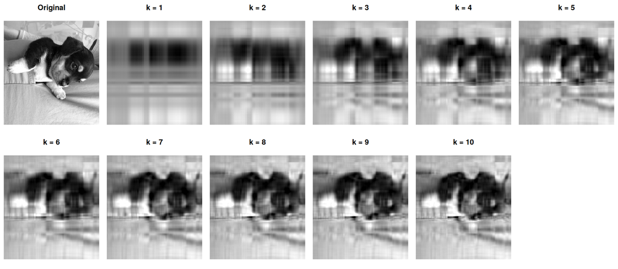

```r
plot_approximations(img3, per_row = 6)
```

### Approximation error

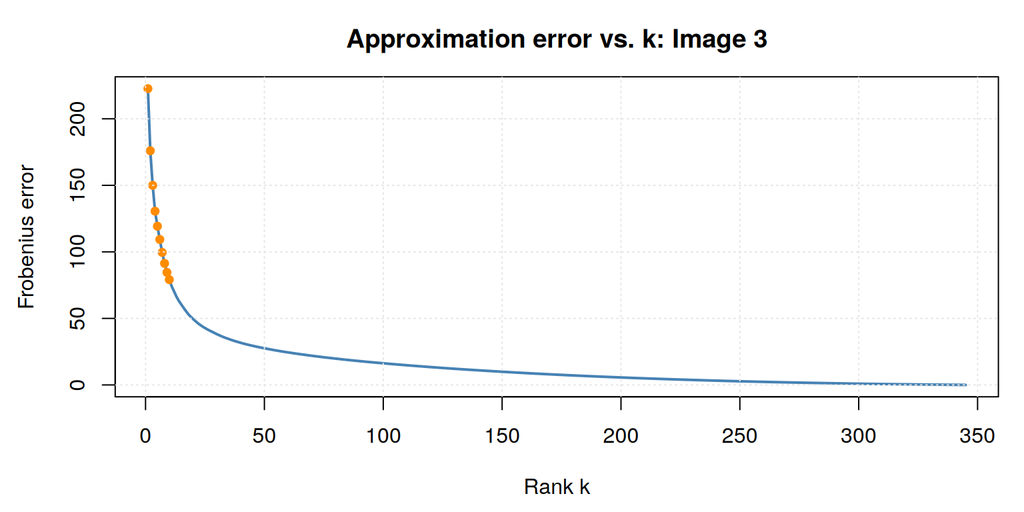

```r
err3 <- plot_error_curve(img3, "Image 3")
```

```r
variance_table(img3)
```

```
##    k cumulative_proportion
## 1  1                0.6178
## 2  2                0.7611
## 3  5                0.8903
## 4 10                0.9517
## 5 20                0.9811
## 6 50                0.9941
```

### First eigenvector and first PC score

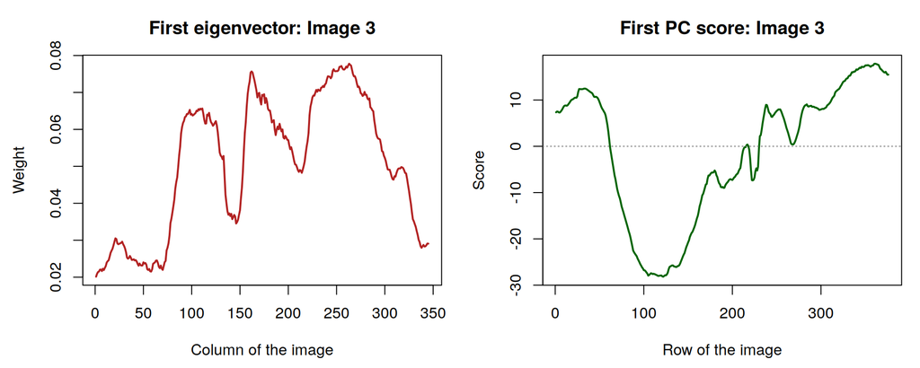

```r
c3 <- plot_first_components(img3, "Image 3")
```

```r
## Smallest and largest weights in the first eigenvector
range(c3$u1)
```

```
## [1] 0.02013664 0.07776903
```

```r
## How closely the scores follow the row averages
cor(c3$z1, rowMeans(img3))
```

```
## [1] 0.9963155
```

**Interpretation.** Every weight in the first eigenvector has the same sign, so the first component adds the columns together rather than setting one part of the frame against another. The weights are far from equal, though. They run from 0.020 to 0.078, lowest near both edges and especially over the first 75 or so columns on the left, and highest in several bands through the middle and right of the frame. Those columns count for more in each score.

The first PC score gives one value per row and tracks how bright that row is. It correlates with the row averages at 0.996. The scores fall below zero from roughly row 60 to row 230, which is where the puppy’s dark head and body sit, and rise above zero near the top of the frame and toward the bottom, where the background and bedding are lighter. The score can take both signs because image 3 holds negative values as well as positive ones, as the range printed above shows.

Multiplying the two together gives a rank 1 image in which every row has the same horizontal shape, scaled up or down. The $k = 1$ panel shows exactly that structure: a darker block across the rows where the puppy sits, vertical banding from the uneven weights, and no recognizable subject, since a single outer product cannot change the pattern from one row to the next.

### How large does $k$ need to be?

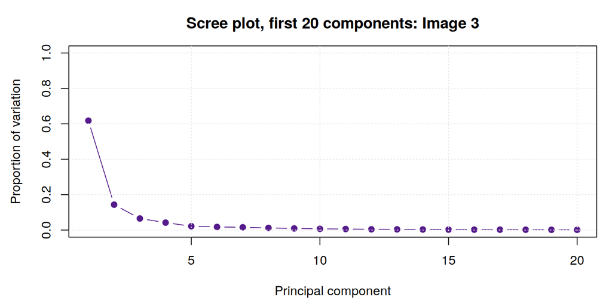

```r
lambda3 <- eigenvalues(img3)
plot_scree(lambda3, "Image 3")
```

The eigenvalues fall away quickly instead of leveling off, which is how a real photograph behaves. It takes 6 components to reach 90% of the total sum of squares, 10 to reach 95%, and 33 to reach 99%. The scree plot bends after the second or third component, and the elbow rule described in ISLR would stop there. That rule is meant for choosing how many components to plot or interpret, though, and the $k = 3$ panel is far from a usable picture. For compression the test is the picture itself. The puppy becomes identifiable around $k = 5$ or $k = 6$, and by $k = 10$ the head and the white paw are clear, though edges are still soft and streaks run across the bedding. The comparison below sets $k = 10$ and $k = 30$ next to the original.

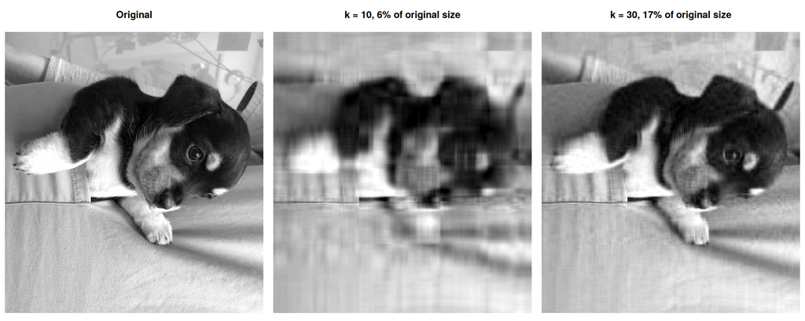

```r
plot_selected(img3, c(10, 30))
```

**I would choose $k = 30$ for this image.** By that point the error curve has flattened, the approximation holds 98.9% of the total sum of squares, and most of the streaking visible at $k = 10$ has faded. It still buys real compression: storing 30 components takes $30 \times (376 + 345) = 21{,}630$ numbers against 129,720 for the original, about 17% of the original size. If the image only needed to be recognizable rather than clean, $k = 10$ would do at about 6%.

## Image 4

```r
img4 <- data.matrix(read_csv("image4.csv"))
dim(img4)
```

```
## [1] 213 119
```

```r
range(img4)
```

```
## [1] -2.659034  6.412563
```

### Original and the first ten approximations

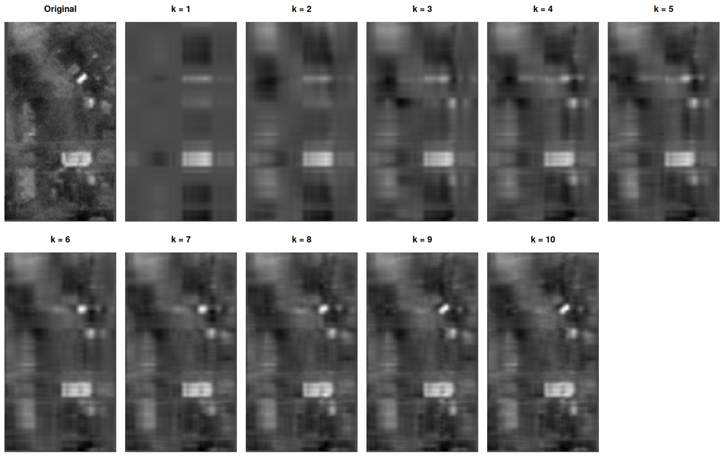

```r
plot_approximations(img4, per_row = 6)
```

### Approximation error

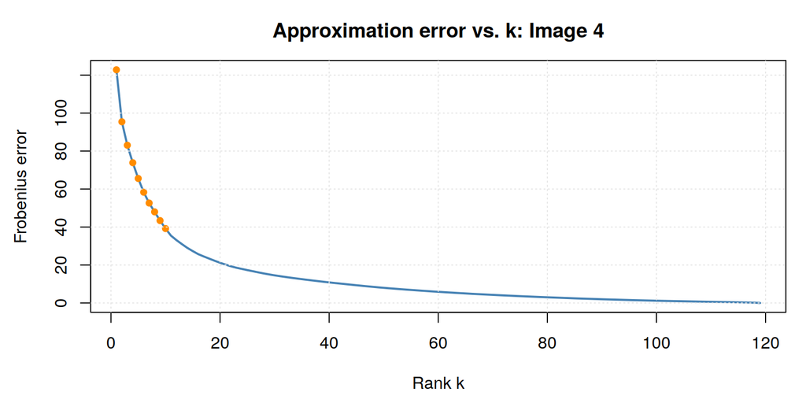

```r
err4 <- plot_error_curve(img4, "Image 4")
```

```r
variance_table(img4)
```

```
##    k cumulative_proportion
## 1  1                0.4050
## 2  2                0.6408
## 3  5                0.8304
## 4 10                0.9394
## 5 20                0.9823
## 6 50                0.9975
```

### First eigenvector and first PC score

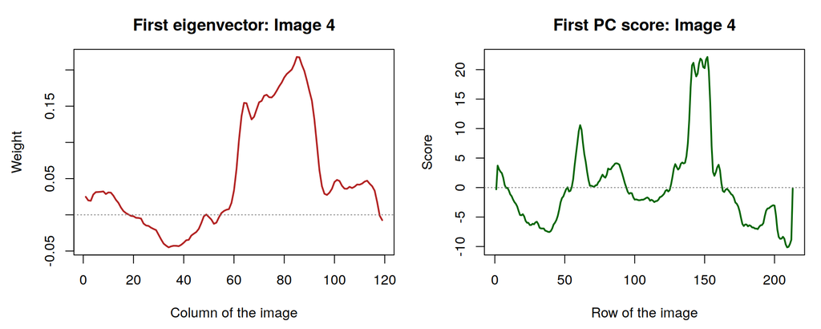

```r
c4 <- plot_first_components(img4, "Image 4")
```

```r
## Columns where the eigenvector's weights are largest
range(which(c4$u1 > 0.1))
```

```
## [1] 62 92
```

```r
## The ten rows with the largest scores
top4 <- sort(order(c4$z1, decreasing = TRUE)[1:10])
top4
```

```
##  [1] 141 142 146 147 148 149 150 151 152 153
```

```r
## How closely the scores follow the row averages
cor(c4$z1, rowMeans(img4))
```

```
## [1] 0.7940707
```

**Interpretation.** The first eigenvector here looks nothing like the smooth profile in image 3. Its weights sit close to zero across most of the width, dip slightly below zero between roughly columns 20 and 55, and rise to a tall plateau between columns 62 and 92, where they reach about 0.22. The first component depends mostly on that one vertical band of the image.

The first PC score is modest for most rows. Its ten largest values all fall between rows 141 and 153, and a second, smaller peak sits near row 60. Those coordinates match the bright rectangle in the lower middle of the original and the bright spot above it, so the leading component in this image locates the brightest object in the scene rather than an overall brightness level. The score drops below zero higher up in the frame and near the bottom, where the same band of columns is darker than usual. The $k = 1$ panel shows the result: its contrast sits in one vertical band, bright where the rectangle and the spot are and dark above and below them, with a nearly flat grey everywhere else.

Because each score depends on a narrow band of columns far more than on the rest of the row, the score follows the row averages only loosely, correlating at 0.79 against 0.996 for image 3. The mixed signs in the eigenvector also say something about the data. An image with no negative values produces a first eigenvector whose weights share one sign, so image 4 must hold negative values as well as positive ones, which the range printed above confirms.

### How large does $k$ need to be?

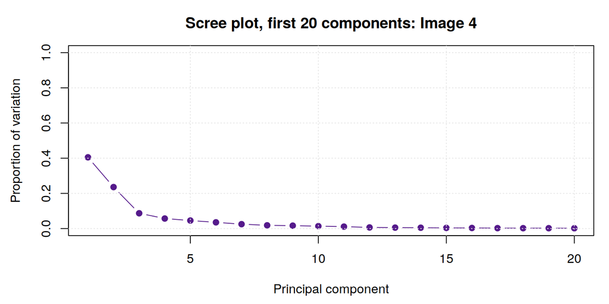

```r
lambda4 <- eigenvalues(img4)
plot_scree(lambda4, "Image 4")
```

This image spreads its sum of squares more evenly across components than image 3 does. The first component holds 40.5% of the total, against 61.8% for image 3, and it takes 8 components to pass 90% and 28 to pass 99%. The scree plot bends after the second or third component here as well, and the same caution about the elbow rule applies. The bright spots in the scene are visible by $k = 5$, but the surrounding texture stays smeared well past $k = 10$.

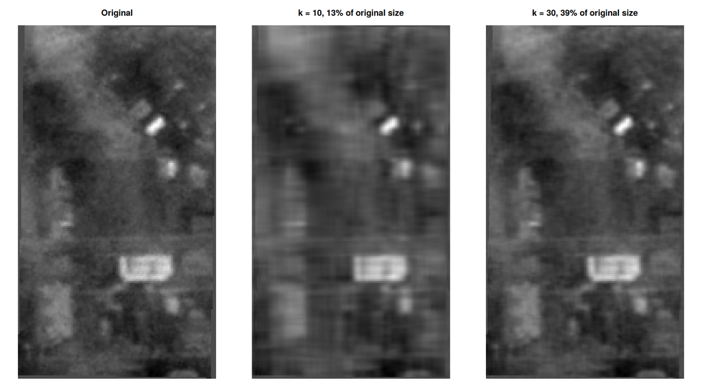

```r
plot_selected(img4, c(10, 30))
```

**I would choose $k = 30$ here as well.** Reaching 99% of the total takes 28 components, and the texture keeps improving past $k = 10$ in a way the first two images do not. At $k = 30$ the storage cost is $30 \times (213 + 119) = 9{,}960$ numbers against 25,347 for the original, about 39% of the original size. The compression is weaker than for image 3 because an image whose variation is spread across many components leaves less redundancy for PCA to exploit.

## Summary

```r
images <- list(img1, img2, img3, img4)
lambdas <- list(lambda1, lambda2, lambda3, lambda4)
chosen <- c(1, 1, 30, 30)
rows <- sapply(images, nrow)
cols <- sapply(images, ncol)

summary_table <- data.frame(
        image = paste("Image", 1:4),
        rows = rows,
        columns = cols,
        k_90 = sapply(lambdas, components_needed, share = 0.90),
        k_95 = sapply(lambdas, components_needed, share = 0.95),
        k_99 = sapply(lambdas, components_needed, share = 0.99),
        chosen_k = chosen,
        numbers_stored = chosen * (rows + cols),
        percent_of_original = round(100 * chosen * (rows + cols) / (rows * cols), 1)
)
knitr::kable(summary_table,
             col.names = c("Image", "Rows", "Columns", "k for 90%",
                           "k for 95%", "k for 99%", "Chosen k",
                           "Numbers stored", "% of original size"))
```

| Image | Rows | Columns | k for 90% | k for 95% | k for 99% | Chosen k | Numbers stored | % of original size |
| --- | --- | --- | --- | --- | --- | --- | --- | --- |
| Image 1 | 1000 | 100 | 38 | 63 | 91 | 1 | 1100 | 1.1 |
| Image 2 | 1000 | 100 | 1 | 1 | 1 | 1 | 1100 | 1.1 |
| Image 3 | 376 | 345 | 6 | 10 | 33 | 30 | 21630 | 16.7 |
| Image 4 | 213 | 119 | 8 | 11 | 28 | 30 | 9960 | 39.3 |

The four images fall into two groups. Images 1 and 2 each contain one real component, plus noise in the case of image 1, so rank 1 is enough and the compression is dramatic. Images 3 and 4 are photographs whose variation is spread across many components, and they need a few dozen components before the approximation stops visibly improving. How much PCA can compress an image depends on how quickly its eigenvalues decay, and that is a property of the image rather than of the method.